# Homework 2

Nikita Grabher-Meyer

10/27/2020

## Hlavac, Marek (2018). stargazer: Well-Formatted Regression and Summary Statistics Tables.

## R package version 5.2.2. https://CRAN.R-project.org/package=stargazer

### Setup: set working directory, install and activate necessary packages

# Data Analysis

### Load data set

```r
load("/Users/nikitagrabher-meyer/Desktop/PHD/Econometrics/ceosal2.RData")
dt.ceo.salaries <- data.table(data)
rm(data)
```

### Descriptive statistics

*How many CEOS are in the sample?*

```r
nrow(dt.ceo.salaries)
```

```
## [1] 177
```

*How many CEOS have a graduate degree?*

```r
nrow(dt.ceo.salaries[grad==1,])
```

```
## [1] 94
```

*What is the percentage of CEOs with graduate degrees?*

```r
dt.ceo.salaries[, sum(grad)]/nrow(dt.ceo.salaries)
```

```
## [1] 0.5310734
```

*What is the average CEO salary?*

```r
dt.ceo.salaries[, mean(salary)]
```

```
## [1] 865.8644
```

*What is the mean CEO salary for those with a graduate degree?*

```r
dt.ceo.salaries[grad==1, mean(salary)]
```

```
## [1] 864.2128
```

*What is the mean CEO salary for those without a graduate degree?*

```r
dt.ceo.salaries[grad==0, mean(salary)]
```

```
## [1] 867.7349
```

*How many CEOs have/don’t have a college degree?*

```r
dt.ceo.salaries[ , list(n_ceo=.N), by = college]
```

```
##    college n_ceo
## 1:       1   172
## 2:       0     5
```

*Can we say that the mean salary is statistically different from 800?*

```r
t.test(dt.ceo.salaries[, salary], mu = 800)
```

```
##
##  One Sample t-test
##
## data:  dt.ceo.salaries[, salary]
## t = 1.4913, df = 176, p-value = 0.1377
## alternative hypothesis: true mean is not equal to 800
## 95 percent confidence interval:
##  778.7015 953.0274
## sample estimates:
## mean of x
##  865.8644
```

We can not reject the null Hp that the population mean is = 800 (this value is indeed contained in the 95 percent confidence interval: 778.7015 953.0274)

*Is the average salary different for CEOs with a graduate degree and those without?*

```r
t.test(dt.ceo.salaries[grad==0, salary] , dt.ceo.salaries[grad==1, salary])
```

```
##
##  Welch Two Sample t-test
##
## data:  dt.ceo.salaries[grad == 0, salary] and dt.ceo.salaries[grad == 1, salary]
## t = 0.038973, df = 149.94, p-value = 0.969
## alternative hypothesis: true difference in means is not equal to 0
## 95 percent confidence interval:
##  -175.0489  182.0932
## sample estimates:
## mean of x mean of y
##  867.7349  864.2128
```

We can not reject the null Hp that there is no difference between the two population means (the value 0 - no difference between the two means - is indeed contained in the 95 percent confidence interval: -175.0489 182.0932)

*Summary table of descriptive statistics*

```r
stargazer(dt.ceo.salaries, type = "text")
```

```
##
## ===================================================================
## Statistic  N    Mean    St. Dev.    Min    Pctl(25) Pctl(75)  Max
## -------------------------------------------------------------------
## salary    177  865.864   587.589    100      471     1,119   5,299
## age       177  56.429     8.422      33       52       62      86
## college   177   0.972     0.166      0        1        1       1
## grad      177   0.531     0.500      0        0        1       1
## comten    177  22.503    12.295      2        12       33      58
## ceoten    177   7.955     7.151      0        3        11      37
## sales     177 3,529.463 6,088.654    29      561     3,500   51,300
## profits   177  207.831   404.454    -463      34      208    2,700
## mktval    177 3,600.316 6,442.276   387      644     3,500   45,400
## lsalary   177   6.583     0.606    4.605    6.155    7.020   8.575
## lsales    177   7.231     1.432    3.367    6.330    8.161   10.845
## lmktval   177   7.399     1.133    5.958    6.468    8.161   10.723
## comtensq  177  656.684   577.123     4       144     1,089   3,364
## ceotensq  177  114.124   212.566     0        9       121    1,369
## profmarg  177   6.420    17.861   -203.077  4.231    10.947  47.458
## -------------------------------------------------------------------
```

### Plots

**Histogram**

*Salary*

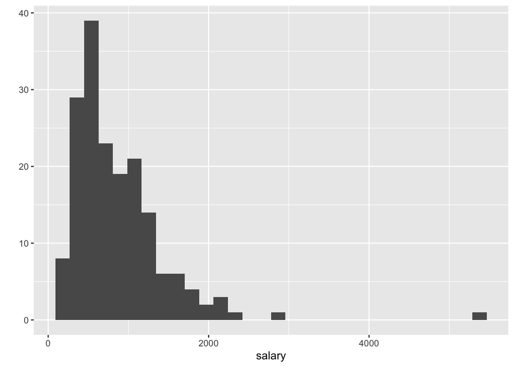

*Age*

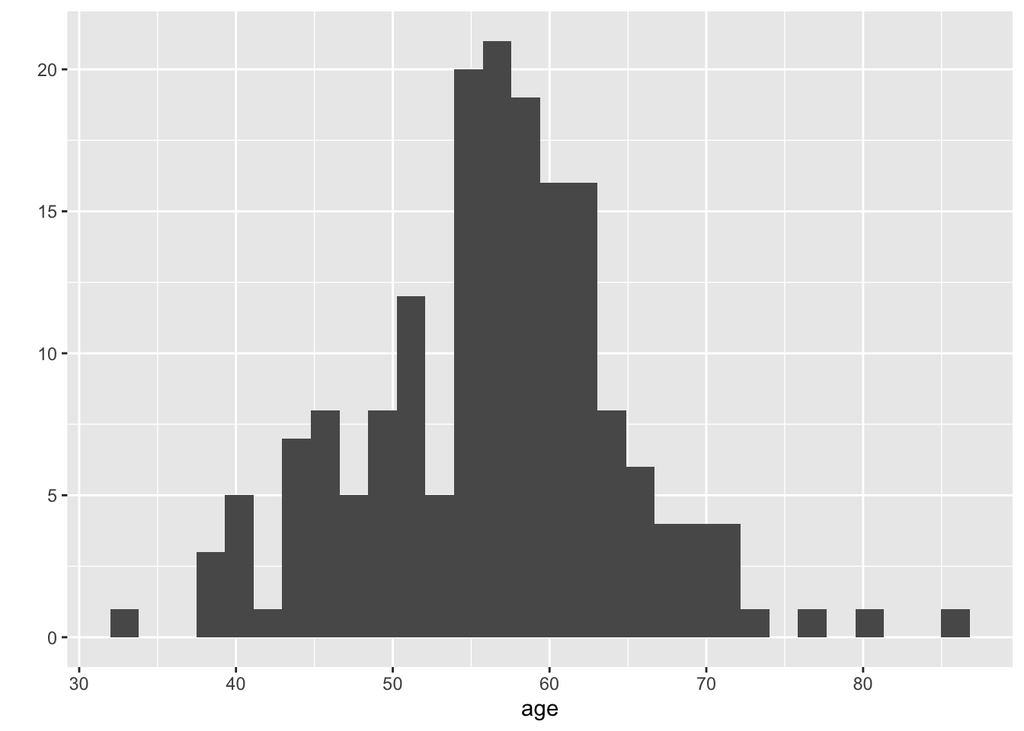

```r
qplot( data = dt.ceo.salaries
, x = age
, geom = "histogram")
```

**Scatterplot**

*Sales vs profits*

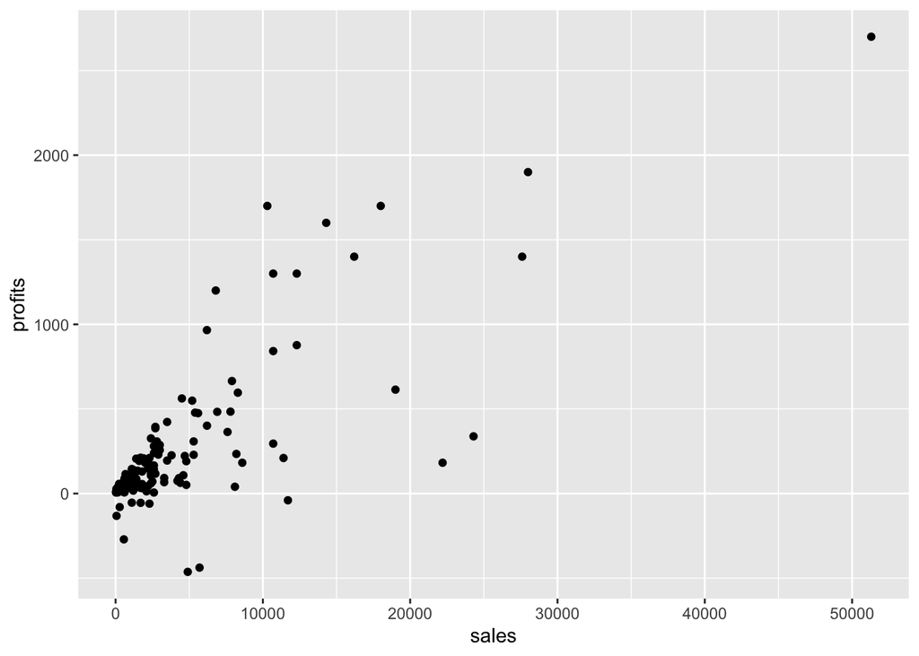

```r
qplot( data = dt.ceo.salaries
, x = sales
, y = profits
, geom = "point")
```

**Barplot**

*Graduate*

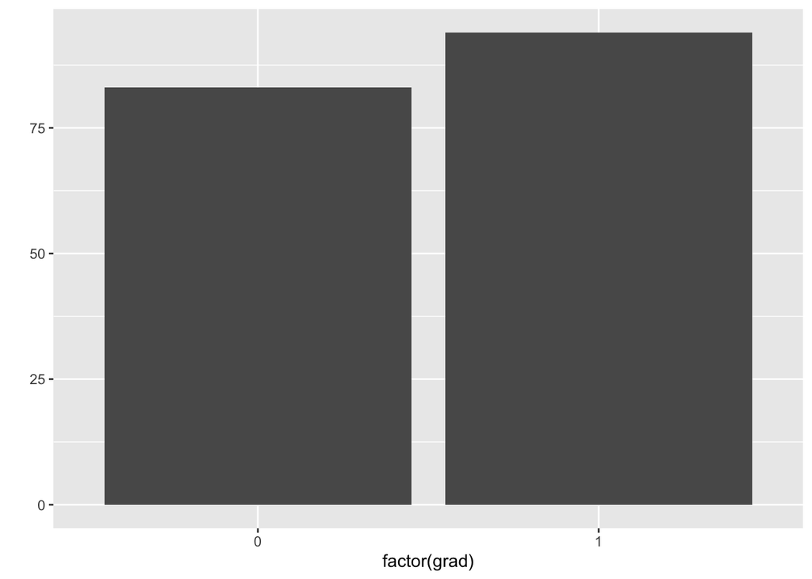

```r
qplot( data = dt.ceo.salaries
, x = factor(grad)
, geom = "bar")
```

**Line**

*Sales vs profits*

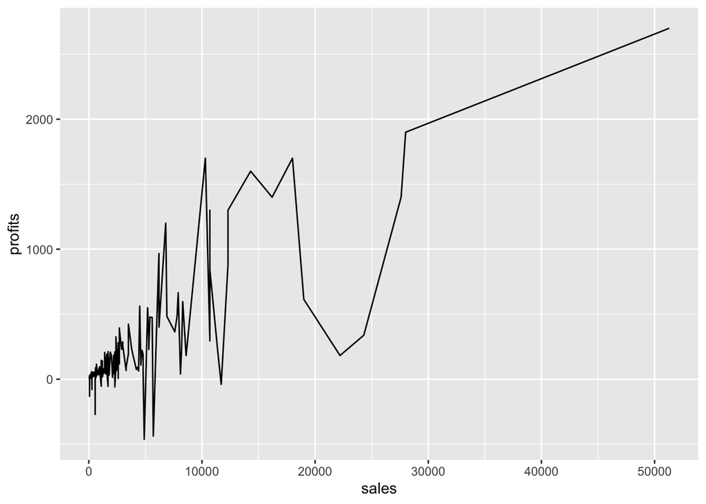

```r
qplot( data = dt.ceo.salaries
, x = sales
, y = profits
, geom = "line")
```

**Facet wrap**

*Salary*

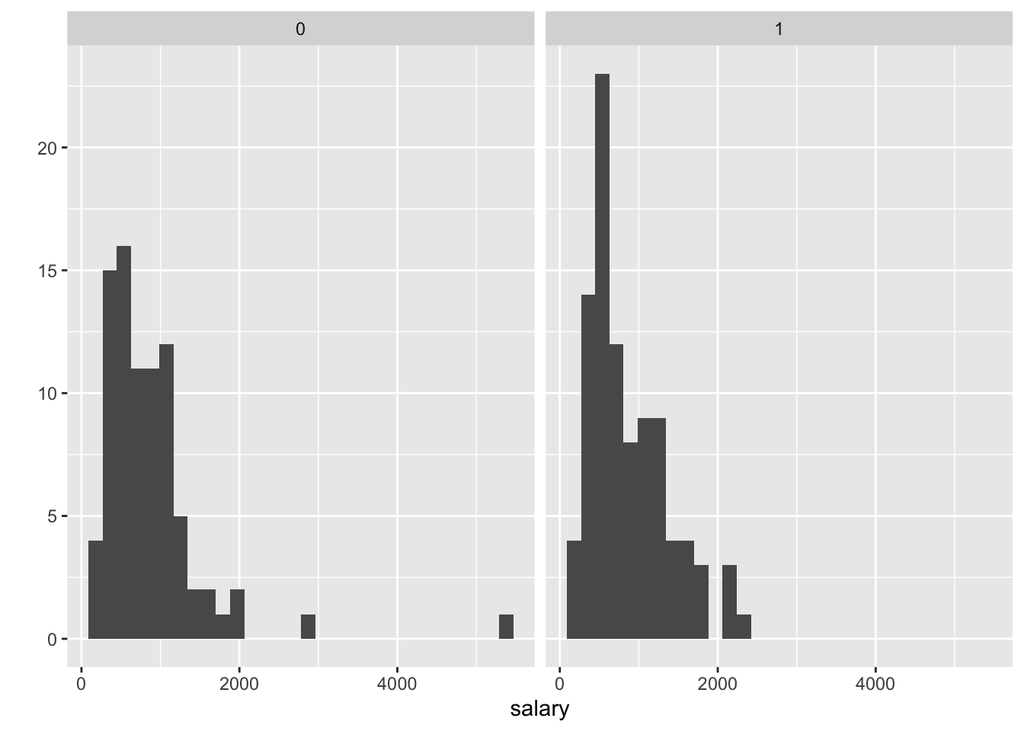

```r
qplot( data = dt.ceo.salaries
, x = salary
, geom = "histogram") + facet_wrap(~ grad)
```

**Customized plots**

*Salary of graduates vs non graduates*

[figure not shown]

```r
qplot( data = dt.ceo.salaries
, x = salary
, geom = "histogram"
, fill = factor(grad, levels = c(0,1), labels = c("Yes", "No"))) +
theme_bw() +
ylim(0,50) +
xlim(0, 4000) +
labs( title = "MY PLOT", x = "CEO Salary", y = "Number of CEOs", fill = "Grad. Degree")
```